# Fourth Week: Hypothesis Testing

TIMSS Analysis

امین رخشا ۹۵۱۰۹۳۱۵

2018-03-08 23:34:48

# تمرین سری چهارم: چقدر ریاضی بلدیم و چرا؟

لطفا مقاله زیر را مطالعه بفرمایید.

[چرایی رتبه ضعیف ایران در آزمون تیمز](https://goo.gl/gX8DZc)

> با استفاده از داده های ارزیابی تیمز ۲۰۱۵ ادعاهای زیر را مورد ارزیابی قراردهید. برای هر سوال علاوه بر استدلال آماری که در غالب آزمون فرض تعریف می شود از تصویرسازی مناسب باهر دو ابزار ggplot2 و highcharter استفاده نمایید. به دلخواه به هفت گزاره از موارد زیر پاسخ دهید.

## کارهای اولیه

```r
library(readr)
library(dplyr)
library(tidyr)
library(ggplot2)
library(highcharter)
library(ggthemes)
library(readxl)
library(coin)

bsa_rds = read_rds('timss_data/bsa.rds')
bts_rds = read_rds('timss_data/bts.rds')
btm_rds = read_rds('timss_data/btm.rds')
bst_rds = read_rds('timss_data/bst.rds')
bsg_rds = read_rds('timss_data/bsg.rds')
bcg_rds = read_rds('timss_data/bcg.rds')
theme_set(theme_gdocs())
```

۱. میران رضایت معلمان در پیشرفت تحصیلی دانش آموزان موثر است.

برای به دست آوردن میزان رضایت معلمان از میانگین پاسخ آن ها به بخش های سوال ۱۰ پرسشنامه استفاده کردیم. با توجه به تقریبا پیوسته بودن دو متغیر از کوریلیشن تست با روش spearman استفاده می کنیم که معایب روش pearson را ندارد و برای اینجا مناسب است. می بینیم که میزان رضایت معلم لزوما در پیشرفت دانش آموزان تاثیری ندارد. در نمودارها نقاط قرمز میانگین امتیاز برای آن مقدار رضایت هستند.

```r
teacherSatisfaction = rbind (
    bts_rds %>% select(idcntry:idlink, btbg10a:btbg10g) %>% mutate(subject = 'sci'),
    btm_rds %>% select(idcntry:idlink, btbg10a:btbg10g) %>% mutate(subject = 'math')
  ) %>%
  gather(key = "question", value = "answer", btbg10a:btbg10g) %>%
  group_by(idcntry, idschool, itcourse, idtealin, idteach, idlink, subject) %>%
  summarise(satisfaction = 4 - mean(answer))

links = bst_rds %>%
  select(idcntry:idsubj)

studentScores = bsa_rds %>%
  select(idcntry:idstud, bsmmat01:bsssci05) %>%
  mutate(math = (bsmmat01 + bsmmat01 + bsmmat01 + bsmmat01 + bsmmat05) / 5,
         sci = (bsssci01 + bsssci02 + bsssci03 + bsssci04 + bsssci05) / 5) %>%
  gather(key = "subject", value = "score", math:sci) %>%
  group_by(idcntry, idbook, idschool, idclass, idstud, subject) %>%
  summarise(score = mean(score))

studentScores = left_join(
  studentScores,
  links
)

studentScores = left_join(
  studentScores,
  teacherSatisfaction
)

filteredScores = studentScores %>%
  filter(!is.na(score), !is.na(satisfaction))

cor.test(
  filteredScores$satisfaction,
  filteredScores$score,
  alternative = "greater",
  method = 'spearman')
```

```
##
##  Spearman's rank correlation rho
##
## data:  filteredScores$satisfaction and filteredScores$score
## S = 4.4939e+16, p-value = 1
## alternative hypothesis: true rho is greater than 0
## sample estimates:
##         rho
## -0.01819415
```

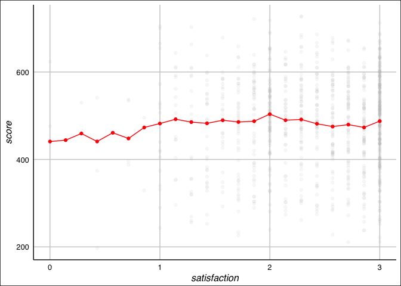

```r
means = filteredScores %>%
  group_by(satisfaction) %>%
  summarise(avgScore = round(mean(score), 2))

plotData = filteredScores %>% rowwise() %>% sample_n(1000)
ggplot() +
  geom_point(data = plotData, aes(x = satisfaction, y = score), color = 'gray', alpha = 0.1) +
  geom_point(data = means, aes(x = satisfaction, y = avgScore), color = 'red') +
  geom_line(data = means, aes(x = satisfaction, y = avgScore), color = 'red')
```

```r
plotData %>%
  hchart(type = 'scatter',
         hcaes(x = satisfaction, y = score),
         color = 'rgba(130, 130, 130, 0.2)',
         enableMouseTracking = FALSE) %>%
  hc_add_series(data = means, type = 'line', hcaes(x = satisfaction, y = avgScore), name = 'average', color = 'red')
```

[interactive chart not shown]

***

۲. والدینی که تحصیلات بیشتری دارند دارای فرزندان موفق تری می باشند.

برای بررسی تفاوت نمره بین گروه های با تحصیلات متفاوت والدینشان، از تست anova استفاده می کنیم. می بینیم که نمره در بین گروه ها متفاوت است. مشکل این تست این است که صرفا تفاوت گروه ها را نتیجه می دهد. برای این که جهت تاثیر تحصیلات والدین یعنی این که تاثیر مثبت دارد را بفهمیم، طبق صحبت استاد در این تمرین بررسی دو گروه اول آخر با t-test کفایت می کند و ترکیب این تست با anova برای این تمرین کافی است. گروه اول و آخر را هم مقایسه می کنیم و می بینیم که تحصیلات والدین بسیار در نمره فرزنداشان موثر است.

```r
parentEducation = bsg_rds %>%
  select(idcntry:idgrade, bsbg07a:bsbg07b) %>%
  rename(mother = bsbg07a, father = bsbg07b) %>%
  gather(key = 'parent', value = 'education', mother:father) %>%
  filter(education != 8)

studentScores = left_join(
  studentScores,
  parentEducation
)

filteredScores = studentScores %>%
  filter(!is.na(score), !is.na(education)) %>%
  mutate(education = as.numeric(education), score = as.numeric(score))

summary(aov(
  score ~ education,
  data = filteredScores))
```

```
##                  Df    Sum Sq   Mean Sq F value Pr(>F)
## education         1 2.625e+09 2.625e+09  267124 <2e-16 ***
## Residuals   1915778 1.883e+10 9.828e+03
## ---
## Signif. codes:  0 '***' 0.001 '**' 0.01 '*' 0.05 '.' 0.1 ' ' 1
```

```r
t.test(
  filteredScores %>% filter(education == 1) %>% .$score,
  filteredScores %>% filter(education == 7) %>% .$score
)
```

```
##
##  Welch Two Sample t-test
##
## data:  filteredScores %>% filter(education == 1) %>% .$score and filteredScores %>% filter(education == 7) %>% .$score
## t = -374.27, df = 397750, p-value < 2.2e-16
## alternative hypothesis: true difference in means is not equal to 0
## 95 percent confidence interval:
##  -115.1350 -113.9354
## sample estimates:
## mean of x mean of y
##  413.8343  528.3695
```

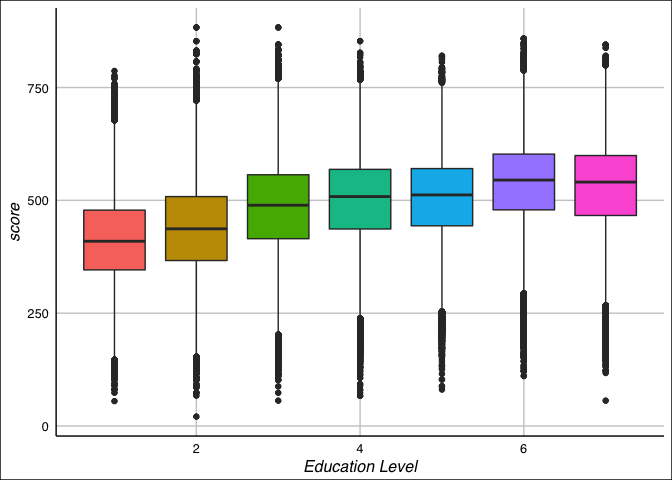

```r
ggplot(filteredScores, aes(group = education, y = score, x = education, fill = as.factor(education))) +
  geom_boxplot() +
  labs(x = 'Education Level') +
  guides(fill = F)
```

```r
hcboxplot(x = filteredScores$score,
          var = filteredScores$education,
          outliers = F) %>%
  hc_chart(type = "column") %>%
  hc_title(text = "Parent's Education and Score Relation") %>%
  hc_xAxis(title = list(text = "Education Level")) %>%
  hc_yAxis(title = list(text = "Score"))
```

[interactive chart not shown]

۳. امکانات رفاهی در خانه موجب پیشرفت تحصیلی می گردد.

از میانگین جواب افراد به بخش های مختلف سوال ۶ برای سنجش امکانات رفاهی استفاده می کنیم. برای آزمون فرض مثل سوال قبل عمل می کنیم و میبینم که امکانات رفاهی تاثیر به سزایی در نمره دارد.

```r
homeState = bsg_rds %>%
  select(idcntry:idgrade, bsbg06a:bsbg06g) %>%
  gather(key = 'question', value = 'existence', bsbg06a:bsbg06g) %>%
  group_by(idcntry, idbook, idschool, idclass, idstud, idgrade) %>%
  summarise(state = 2 - mean(existence))

studentScores = left_join(
  studentScores,
  homeState
)

filteredScores = studentScores %>%
  filter(!is.na(score), !is.na(state)) %>%
  mutate(state = as.numeric(state), score = as.numeric(score))

summary(aov(
  score ~ state,
  data = filteredScores))
```

```
##                  Df    Sum Sq   Mean Sq F value Pr(>F)
## state             1 2.098e+09 2.098e+09  214208 <2e-16 ***
## Residuals   2111146 2.067e+10 9.793e+03
## ---
## Signif. codes:  0 '***' 0.001 '**' 0.01 '*' 0.05 '.' 0.1 ' ' 1
```

```r
t.test(
  filteredScores %>% filter(state == 0) %>% .$score,
  filteredScores %>% filter(state == 1) %>% .$score
)
```

```
##
##  Welch Two Sample t-test
##
## data:  filteredScores %>% filter(state == 0) %>% .$score and filteredScores %>% filter(state == 1) %>% .$score
## t = -239.03, df = 27665, p-value < 2.2e-16
## alternative hypothesis: true difference in means is not equal to 0
## 95 percent confidence interval:
##  -136.1111 -133.8971
## sample estimates:
## mean of x mean of y
##  383.1744  518.1785
```

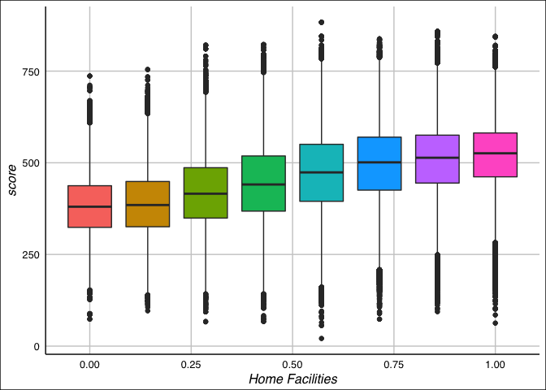

```r
ggplot(filteredScores, aes(group = state, y = score, x = state, fill = as.factor(state))) +
  geom_boxplot() +
  labs(x = 'Home Facilities') +
  guides(fill = F)
```

```r
hcboxplot(x = filteredScores$score,
          var = round(filteredScores$state, 1),
          outliers = F) %>%
  hc_chart(type = "column") %>%
  hc_title(text = "Home Facilities and Score Relation") %>%
  hc_xAxis(title = list(text = "Home Facilities")) %>%
  hc_yAxis(title = list(text = "Score"))
```

[interactive chart not shown]

۴. محیط آرام مدرسه نقش مهمی در پیشرفت تحصیلی دارد.

۵. معلمان با تحصیلات بالاتر یا تجربه بیشتر دانش آموزان موفق تری تربیت می کنند.

۶. پسران در کاربرد هندسه قوی تر هستند.

چون در داده Plausible Value برای کاربرد هندسه نداریم مجبوریم خودمان آن را برای دانش آموزان بفهمیم. برای هر سوال، مقدار داده شده بیانگیر چیز متفاوتی است. برای برخی سوالات درستی، نادرستی یا پاسخ ناقص و برای بعضی گزینه ی انتخاب شده توسط دانش آموزان آمده است. این که کدام مقدار بیانگر کدام موضوع است هم بین سوالات متفاوت است. این که مقدار داده شده در داده بیانگر چیست و کلید سوالات تستی در فایل اکسل codebook داده شده است. آن را می خوانیم و با آن نمره دانش آموزان در سوالات مختلف را محاسبه می کنیم. همانطور که می بینید کار آسانی نیست! در نهایت برای هر سوال و دانش آموز به ۳ حالت درست، نادرست و نیمه درست می رسیم که به ترتیب نمره ی ۱۰۰، ۰ و ۵۰ را به آن می دهیم. با توجه به معلوم نبودن توزیع نمرات، از permutation test برای مقایسه بین دختران و پسران استفاده می کنیم. همانطور که می بینید پسران در این زمینه بهتر هستند.

```r
qdata1 = bind_rows(
          read_xlsx('timss_data/T15_G8_ItemInformation.xlsx', sheet = 'MAT'),
          read_xlsx('timss_data/T15_G8_ItemInformation.xlsx', sheet = 'SCI'))
qdata2 = read_xlsx('timss_data/T15_G8_Codebook.xlsx', sheet = 'BSA')
qdata = left_join(
  qdata1 %>% rename(question = `Item ID`),
  qdata2 %>% rename(question = Variable),
  by = 'question'
)
qdata$`Value Scheme Detailed` = as.factor(qdata$`Value Scheme Detailed`)
qdata$markingType = as.numeric(qdata$`Value Scheme Detailed`)
qdata$question = tolower(qdata$question)
qdata$Key = replace(qdata$Key, qdata$Key == 'A', 1) %>%
  replace(qdata$Key == 'B', 2) %>%
  replace(qdata$Key == 'C', 3) %>%
  replace(qdata$Key == 'D', 4)
qdata$Key = as.numeric(qdata$Key)

geometryApplyingQuestions = qdata %>%
  filter(`Content Domain` == 'Geometry', `Cognitive Domain` == 'Applying') %>%
  .$question

studentGeomScores = bsa_rds %>%
  select(idcntry:m062120, itsex) %>%
  gather(key = 'question', value = 'value', m042182:m062120) %>%
  filter(question %in% geometryApplyingQuestions) %>%
  select(idcntry, idstud, itsex, question, value) %>%
  filter(!is.na(value)) %>%
  unique()

studentGeomScores = left_join(
  studentGeomScores,
  qdata %>% select(question, Key, markingType, `Maximum Points`),
  by = 'question'
)


#marking schemes:
# View(qdata %>% select(`Value Scheme Detailed`, markingType) %>% unique())

calcScore = function(markingType, value, Key) {
  result = rep(NA, length(value))
  correct = which(
    (!is.na(Key) & (value == Key)) |
    (value >= 19 & value <= 21) |
    (value >= 10 & value <= 12 & markingType < 24)
  )
  partial = which(value >= 10 & value <= 12 & markingType >= 24)
  incorrect = which(
    (!is.na(Key) & value != Key) |
    (value >= 70)
  )
  result[correct] = rep(100, length(correct))
  result[partial] = rep(50, length(partial))
  result[incorrect] = rep(0, length(incorrect))
  return(result)
}

studentGeomScores = studentGeomScores %>%
  mutate(score = calcScore(markingType, value, Key))

testResult = oneway_test(score ~ as.factor(itsex),
                     data = studentGeomScores,
                     alternative = 'less')

testResult
```

```
##
##  Asymptotic Two-Sample Fisher-Pitman Permutation Test
##
## data:  score by as.factor(itsex) (1, 2)
## Z = -9.9857, p-value < 2.2e-16
## alternative hypothesis: true mu is less than 0
```

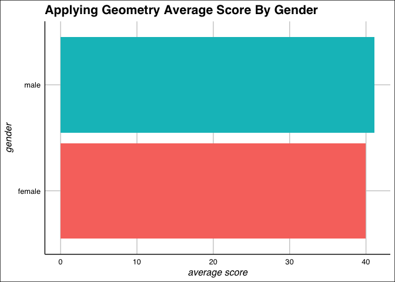

```r
plotData = studentGeomScores %>%
  filter(!is.na(itsex)) %>%
  group_by(itsex) %>%
  summarise(avg = round(weighted.mean(score,  `Maximum Points`), 2)) %>%
  mutate(gender = ifelse(itsex == 1, 'female', 'male')) %>%
  ungroup()


ggplot(plotData, aes(x = gender, y = avg, fill = as.factor(gender))) +
  geom_bar(stat = 'identity') +
  labs(fill = 'score', y = 'average score') +
  coord_flip() +
  guides(fill = F) +
  labs(title = 'Applying Geometry Average Score By Gender')
```

```r
hchart(plotData, type = 'bar', hcaes(x = gender, y = avg, color = as.factor(gender))) %>%
  hc_title(text = "Applying Geometry Average Score By Gender")
```

[interactive chart not shown]

۷. تغذیه دانش آموزان نقش اساسی در یادگیری آنها دارد.

```r
breakfast = bsg_rds %>%
  select(idcntry:idgrade, bsbg12) %>%
  rename(breakfast = bsbg12) %>%
  mutate(breakfast = 4 - as.numeric(breakfast))

studentScores = left_join(
  studentScores,
  breakfast
)

filteredScores = studentScores %>%
  filter(!is.na(score), !is.na(breakfast)) %>%
  mutate(breakfast = as.numeric(breakfast), score = as.numeric(score))

summary(aov(
  score ~ state,
  data = filteredScores))
```

```
##                  Df    Sum Sq   Mean Sq F value Pr(>F)
## state             1 2.082e+09 2.082e+09  213054 <2e-16 ***
## Residuals   2099512 2.052e+10 9.772e+03
## ---
## Signif. codes:  0 '***' 0.001 '**' 0.01 '*' 0.05 '.' 0.1 ' ' 1
## 118172 observations deleted due to missingness
```

```r
t.test(
  filteredScores %>% filter(breakfast == 0) %>% .$score,
  filteredScores %>% filter(breakfast == 3) %>% .$score
)
```

```
##
##  Welch Two Sample t-test
##
## data:  filteredScores %>% filter(breakfast == 0) %>% .$score and filteredScores %>% filter(breakfast == 3) %>% .$score
## t = -45.54, df = 458170, p-value < 2.2e-16
## alternative hypothesis: true difference in means is not equal to 0
## 95 percent confidence interval:
##  -10.21414  -9.37122
## sample estimates:
## mean of x mean of y
##  488.1908  497.9834
```

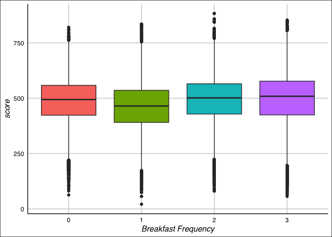

```r
ggplot(filteredScores, aes(group = breakfast, y = score, x = breakfast, fill = as.factor(breakfast))) +
  geom_boxplot() +
  labs(x = 'Breakfast Frequency') +
  guides(fill = F)
```

```r
hcboxplot(x = filteredScores$score,
          var = round(filteredScores$breakfast, 1),
          outliers = F) %>%
  hc_chart(type = "column") %>%
  hc_title(text = "Breakfast Frequency and Score Relation") %>%
  hc_xAxis(title = list(text = "Breakfast Frequency")) %>%
  hc_yAxis(title = list(text = "Score"))
```

[interactive chart not shown]

۸. مدارس با امکانات بیشتر دارای عملکرد بهتری می باشند.

۹. علت افت تحصیلی عدم مشارکت در کلاس است.

دقیقا مانند سوال ۷ عمل می کنیم. می بینیم که حضور در کلاس در نمره تاثیر مثبت دارد.

```r
presence = bsg_rds %>%
  select(idcntry:idgrade, bsbg11) %>%
  rename(presence = bsbg11) %>%
  mutate(presence = as.numeric(presence))

studentScores = left_join(
  studentScores,
  presence
)

filteredScores = studentScores %>%
  filter(!is.na(score), !is.na(presence)) %>%
  mutate(presence = as.numeric(presence), score = as.numeric(score))

summary(aov(
  score ~ presence,
  data = filteredScores))
```

```
##                  Df    Sum Sq   Mean Sq F value Pr(>F)
## presence          1 1.855e+09 1.855e+09  181248 <2e-16 ***
## Residuals   2154036 2.204e+10 1.023e+04
## ---
## Signif. codes:  0 '***' 0.001 '**' 0.01 '*' 0.05 '.' 0.1 ' ' 1
```

```r
t.test(
  filteredScores %>% filter(presence == 1) %>% .$score,
  filteredScores %>% filter(presence == 4) %>% .$score
)
```

```
##
##  Welch Two Sample t-test
##
## data:  filteredScores %>% filter(presence == 1) %>% .$score and filteredScores %>% filter(presence == 4) %>% .$score
## t = -411.21, df = 190320, p-value < 2.2e-16
## alternative hypothesis: true difference in means is not equal to 0
## 95 percent confidence interval:
##  -110.3210 -109.2743
## sample estimates:
## mean of x mean of y
##  396.1093  505.9070
```

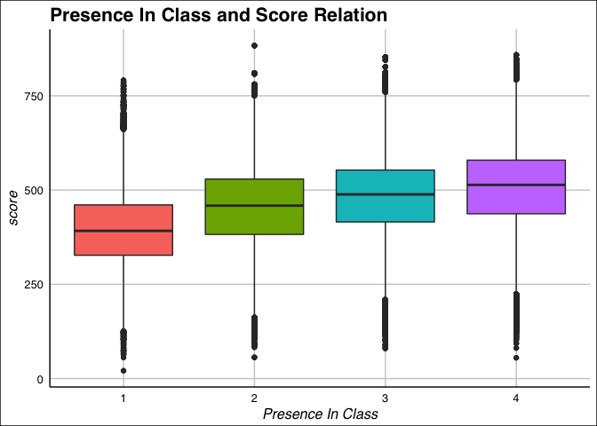

```r
ggplot(filteredScores, aes(group = presence, y = score, x = presence, fill = as.factor(presence))) +
  geom_boxplot() +
  labs(x = 'Presence In Class', title = 'Presence In Class and Score Relation') +
  guides(fill = F)
```

```r
hcboxplot(x = filteredScores$score,
          var = round(filteredScores$presence, 1),
          outliers = F) %>%
  hc_chart(type = "column") %>%
  hc_title(text = "Presence In Class and Score Relation") %>%
  hc_xAxis(title = list(text = "Presence In Class")) %>%
  hc_yAxis(title = list(text = "Score"))
```

[interactive chart not shown]

۱۰. دانش آموزان ایرانی در استدلال قوی تر از کاربرد هستند.

از t test استفاده می کنیم. یک گروه را نمرات کاربرد و دیگری نمرات استدلال در نظر می گیریم . می بینیم که p value بزرگ است پس نمیتوان با این داده ها چنین حرفی زد

```r
studentScores = bsa_rds %>%
  select(idcntry:idstud, bsmapp01:bsmrea05, bssapp01:bssrea05) %>%
  filter(idcntry == 364) %>%
  group_by(idcntry, idbook, idschool, idclass, idstud) %>%
  summarise(
    applying = mean(c(bsmapp01:bsmapp05, bssapp01:bssapp05)),
    reasoning = mean(c(bsmrea01:bsmrea05, bssrea01:bssrea05))
  ) %>%
  gather(key = 'type', value = 'score', applying:reasoning) %>%
  unique()


applying <- studentScores %>% filter(type == 'applying') %>% .$score
reasoning <- studentScores %>% filter(type == 'reasoning') %>% .$score

t.test(reasoning,
       applying,
       alternative = 'less')
```

```
##
##  Welch Two Sample t-test
##
## data:  reasoning and applying
## t = -0.45354, df = 12248, p-value = 0.3251
## alternative hypothesis: true difference in means is less than 0
## 95 percent confidence interval:
##      -Inf 1.909841
## sample estimates:
## mean of x mean of y
##  451.0785  451.8055
```

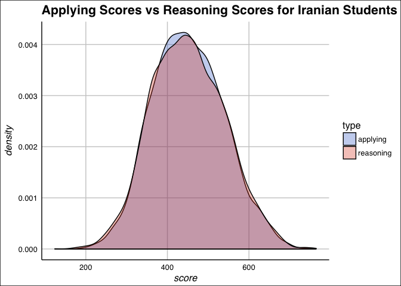

```r
ggplot(data = studentScores, aes(group = type, fill = type, x = score)) +
  geom_density(alpha = 0.3) +
  scale_fill_gdocs() +
  labs(title = 'Applying Scores vs Reasoning Scores for Iranian Students')
```

```r
hchart(type = "area",
       density(applying),
       name = 'applying') %>%
  hc_add_series(type = 'area',
                data = density(reasoning),
                name = 'reasoning') %>%
  hc_title(text = "Applying Scores vs Reasoning Scores for Iranian Students")
```

[interactive chart not shown]

سه گزاره جالب کشف کنید و ادعای خود را ثابت نمایید.

دانش آموزان که یک کنسول بازی در خانه دارند نمرات بهتری می گیرند.

از یکی از سوالات پرسشنامه برای بررسی این موضوع استفاده می کنیم. و t test بین دو گروه این گزاره را نتیجه می دهد.

```r
gamingSystem = bsg_rds %>%
  select(idcntry:idgrade, bsbg06g) %>%
  rename(gamingSystem = bsbg06g) %>%
  mutate(gamingSystem = ifelse(gamingSystem == 1, 'yes', 'no'))

studentScores = bsa_rds %>%
  select(idcntry:idstud, bsmmat01:bsssci05) %>%
  mutate(score = (bsmmat01 + bsmmat01 + bsmmat01 + bsmmat01 + bsmmat05 +
                    bsssci01 + bsssci02 + bsssci03 + bsssci04 + bsssci05) / 10) %>%
  select(idcntry:idstud, score)

studentScores = left_join(
  studentScores,
  gamingSystem
)

filteredScores = studentScores %>%
  filter(!is.na(score), !is.na(gamingSystem)) %>%
  mutate(score = as.numeric(score))

t.test(
  formula = score ~ gamingSystem,
  data = filteredScores,
  alternative = 'less'
)
```

```
##
##  Welch Two Sample t-test
##
## data:  score by gamingSystem
## t = -55.993, df = 204420, p-value < 2.2e-16
## alternative hypothesis: true difference in means is less than 0
## 95 percent confidence interval:
##       -Inf -22.36305
## sample estimates:
##  mean in group no mean in group yes
##          466.5396          489.5794
```

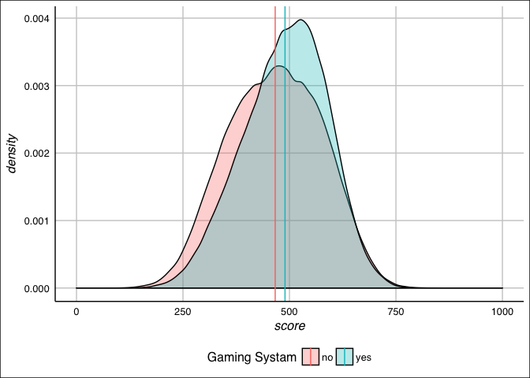

```r
means = filteredScores %>%
  group_by(gamingSystem) %>%
  summarise(avgScore = mean(score))

plotData = filteredScores %>% rowwise() %>% sample_n(1000)


ggplot(data = filteredScores, aes(group = gamingSystem, fill = gamingSystem, x = score)) +
  geom_density(alpha = 0.3) +
  geom_vline(data = means, aes(xintercept = avgScore, color = gamingSystem)) +
  scale_x_continuous(limits = c(0, 1000)) +
  theme(legend.position = 'bottom', legend.direction = 'horizontal') +
  labs(fill = 'Gaming Systam', color  = 'Gaming Systam')
```

```r
withSystem <- filteredScores %>% filter(gamingSystem == 'yes') %>% .$score
withoutSystem <- filteredScores %>% filter(gamingSystem == 'no') %>% .$score

hchart(type = "area",
       density(withSystem),
       name = 'With Gaming System') %>%
  hc_add_series(type = 'area',
                data = density(withoutSystem),
                name = 'Without Gaming System')
```

[interactive chart not shown]

دانش آموزان مهاجر موفق تر هستند.

این که آیا دانش آموز در کشور برگزاری آزمون متولد شده است یا نه در پرسشنامه آمده است. برای مقایسه از t test استفاده می کنیم و میبینم که بین دو گروه تفاوت معنی داری وجود دارد.

```r
immigration = bsg_rds %>%
  select(idcntry:idgrade, bsbg10a) %>%
  rename(immigration = bsbg10a) %>%
  mutate(immigration = ifelse(immigration == 1, 'no', 'yes'))

studentScores = left_join(
  studentScores,
  immigration
)

filteredScores = studentScores %>%
  filter(!is.na(score), !is.na(immigration)) %>%
  mutate(score = as.numeric(score))

t.test(
  formula = score ~ immigration,
  data = filteredScores,
  alternative = 'less'
)
```

```
##
##  Welch Two Sample t-test
##
## data:  score by immigration
## t = -33.872, df = 39237, p-value < 2.2e-16
## alternative hypothesis: true difference in means is less than 0
## 95 percent confidence interval:
##       -Inf -19.61465
## sample estimates:
##  mean in group no mean in group yes
##          477.8467          498.4625
```

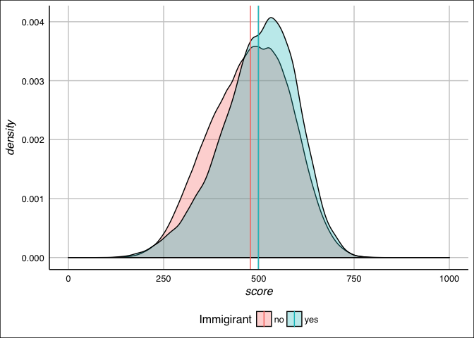

```r
means = filteredScores %>%
  group_by(immigration) %>%
  summarise(avgScore = round(mean(score), 2))

plotData = filteredScores %>% rowwise() %>% sample_n(1000)


ggplot(data = filteredScores, aes(fill = immigration, x = score)) +
  geom_density(alpha = 0.3) +
  geom_vline(data = means, aes(xintercept = avgScore, color = immigration)) +
  scale_x_continuous(limits = c(0, 1000)) +
  theme(legend.position = 'bottom', legend.direction = 'horizontal') +
  labs(fill = 'Immigirant', color  = 'Immigirant')
```

```r
immigirant <- filteredScores %>% filter(immigration == 'yes') %>% .$score
nonimmigirant <- filteredScores %>% filter(immigration == 'no') %>% .$score

hchart(type = "area",
       density(immigirant),
       name = 'Immigirant') %>%
  hc_add_series(type = 'area',
                data = density(nonimmigirant),
                name = 'Nonimmigirant')
```

[interactive chart not shown]

دختران برنامه دارند بیشتر تحصیل کنند.

طول تحصیلات در پرسشنامه از دانش آموزان سوال شده است. با توجه گسسته بودن مقادیر نمی توان نرمال بودن نمرات را فرض کرد. برای همین از permutation test استفاده می کنیم. می بینیم که این تست فرض برابری دو گروه را رد می کند و گزاره را می پذیریم. در نمودارها کسر دانش آموزانی که انتظار دارند تحصیلاتشان را تا آن مقطع ادامه دهند نشان داده شده است. می بینیم که در دختران تمایل به سمت تحصیلات بالاتر بیشتر است.

```r
educationLength = bsg_rds %>%
  select(idcntry:idgrade, bsbg08, itsex) %>%
  rename(educationLength = bsbg08) %>%
  mutate(educationLength = as.numeric(educationLength)) %>%
  mutate(itsex = as.factor(itsex)) %>%
  filter(!is.na(educationLength), !is.na(itsex))

oneway_test(
  educationLength ~ as.factor(itsex),
  data = educationLength,
  alternative = 'greater'
)
```

```
##
##  Asymptotic Two-Sample Fisher-Pitman Permutation Test
##
## data:  educationLength by as.factor(itsex) (1, 2)
## Z = 60.734, p-value < 2.2e-16
## alternative hypothesis: true mu is greater than 0
```

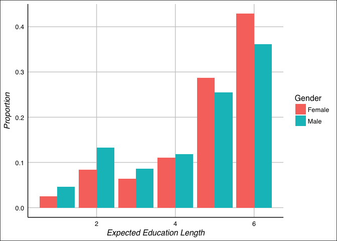

```r
plotData = educationLength %>%
  group_by(itsex) %>%
  mutate(totalCount = n()) %>%
  group_by(itsex, educationLength, totalCount) %>%
  summarise(count = n()) %>%
  mutate(prop = count / totalCount) %>%
  ungroup() %>%
  mutate(itsex = ifelse(itsex == 1, 'Female', 'Male'))

ggplot(plotData, aes(x = educationLength, fill = as.factor(itsex), y = prop)) +
  geom_bar(stat = 'identity', position = 'dodge') +
  labs(fill = 'Gender', x = 'Expected Education Length', y = 'Proportion')
```

```r
hchart(plotData, type = 'bar', hcaes(x = educationLength, group = as.factor(itsex), y = prop)) %>%
  hc_xAxis(title = list(text = 'Expected Education Length')) %>%
  hc_yAxis(title = list(text = 'Proportion'))
```

[interactive chart not shown]